# Homework 1

Name: Antoine Marthey

UNI: am4665

# Exercice 1

- Graph that I don’t like.

Source: http://www.statisticshowto.com/misleading-graphs/

I selected a graph from Fox news which I totally misleading.

First, we are not sure what is the time period that has been selected. Is that an average on the last 5 years? Is that an average on 2011? Is that a specific day during 2011? Source needs to be more detailed.

Second the y axis does not start at 0, which creates a lot of confusion. It seems at first look that the people on welfare are 4 times more important than the people with a full time job. It is actually only 51% of the sample.

[figure not shown]

```r
library(knitr)
knitr::include_graphics('/Users/antoinemarthey/Desktop/File/Fox_welfare-jobs-ff-1.jpg')
```

- Graph that I like.

Source: http://www.ats.ucla.edu/stat/stata/library/GraphExamples/code/line4.htm

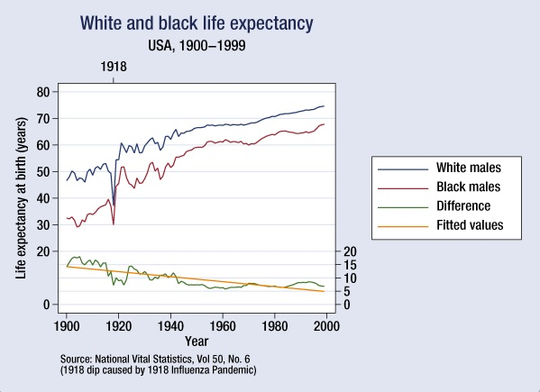

```r
knitr::include_graphics('/Users/antoinemarthey/Desktop/File/life_expect.jpg')
```

# Exercice 2

- Question a:

```r
library(MASS)
layout(matrix(c(2,1,3,3), 2, 2, byrow = FALSE))
hist(galaxies,main='Histogram of Galaxies', xlab = 'Velocities (km/sec)')
plot(density(galaxies), main='Density Graph of Galaxies', xlab = 'Velocities (km/sec)')
```

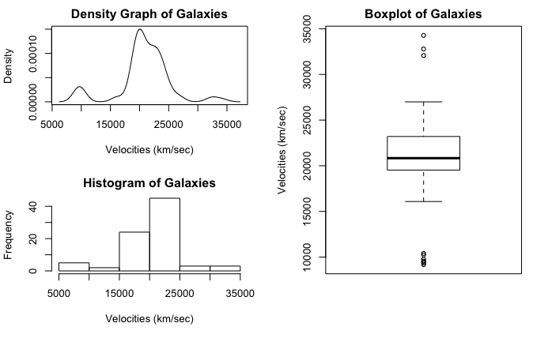

```r
boxplot(galaxies, main = 'Boxplot of Galaxies', ylab = 'Velocities (km/sec)')
```

We can see from the 3 graphs that the data are really spread. The min and max are far from the median. We can see from the 3 graphs that a lot of the data seem to be between 150000 and 25000 but the histogram breaks are to important, i.e 5000. We can refine the spread from the boxplot and the density function. Extreme data can be interpreted as data error, possibly.

- Question b:

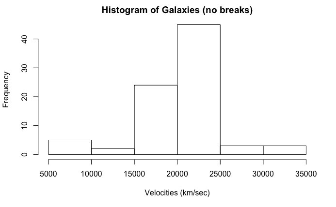

```r
hist(galaxies, main='Histogram of Galaxies (no breaks)', xlab = 'Velocities (km/sec)')
```

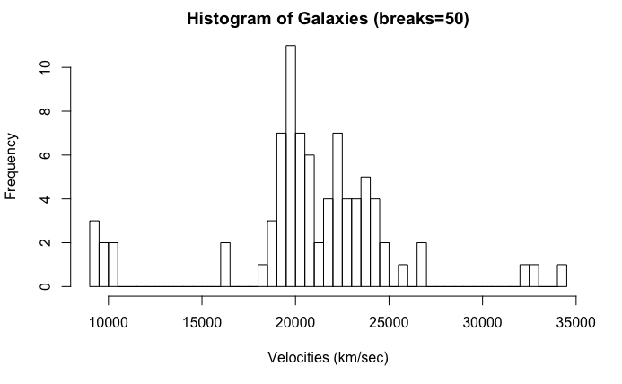

```r
hist(galaxies,breaks=50, main='Histogram of Galaxies (breaks=50)', xlab = 'Velocities (km/sec)')
```

[figure not shown]

```r
hist(galaxies,breaks=200, main='Histogram of Galaxies (breaks=20)', xlab = 'Velocities (km/sec)')
```

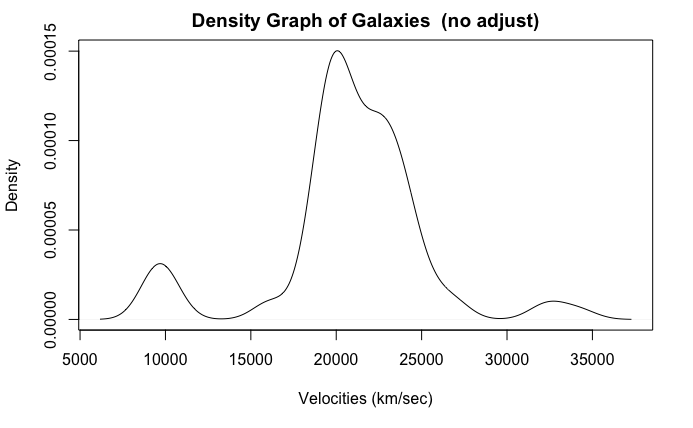

```r
plot(density(galaxies), main='Density Graph of Galaxies  (no adjust)', xlab = 'Velocities (km/sec)')
```

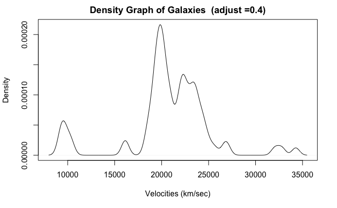

```r
plot(density(galaxies, adjust = 0.4), main='Density Graph of Galaxies  (adjust =0.4)', xlab = 'Velocities (km/sec)')
```

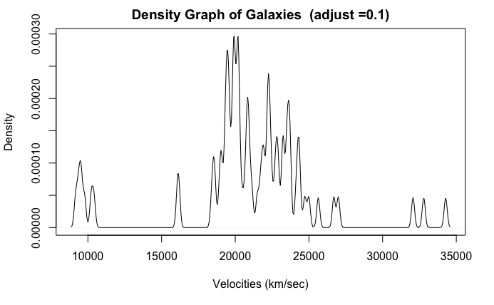

```r
plot(density(galaxies, adjust = 0.1), main='Density Graph of Galaxies  (adjust =0.1)', xlab = 'Velocities (km/sec)')
```

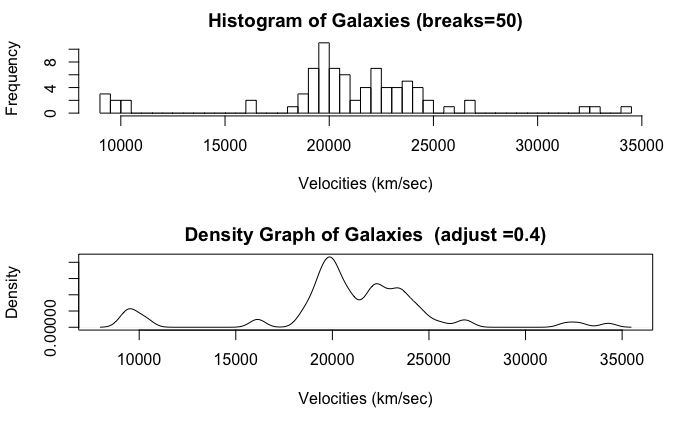

```r
par(mfrow=c(2,1))
hist(galaxies,breaks=50, main='Histogram of Galaxies (breaks=50)', xlab = 'Velocities (km/sec)')
plot(density(galaxies,adjust=0.4), main='Density Graph of Galaxies  (adjust =0.4)', xlab = 'Velocities (km/sec)')
```

By refining the parameters of hist (breaks=50) and density (adjust=0.4) we can get two similars curves. We can also see that the bumps at the extremity of the graph are taken into account.

# Exercice 3:

- Question a:

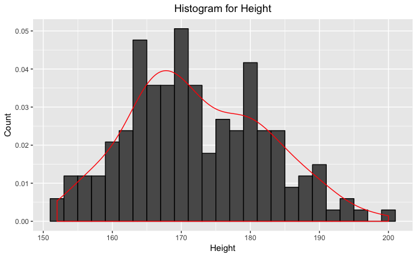

```r
library(ggplot2)
df <- data.frame(na.omit(survey))
ggplot(df, aes(df$Height)) +
 geom_histogram(aes(y =..density..),col=1,binwidth=2) +
 geom_density(col=2) +
 labs(title='Histogram for Height') +
 labs(x='Height', y='Count') +
 theme(plot.title = element_text(hjust = 0.5))
```

There is no clear evidence of binomality. The curve doesn’t look perfectly symetric.

- Question b:

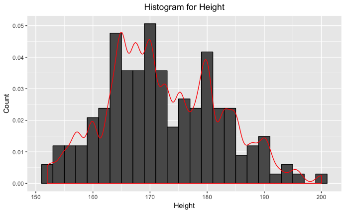

```r
df <- data.frame(na.omit(survey))
ggplot(df, aes(df$Height)) +
 geom_histogram(aes(y =..density..), binwidth = 2,col=1) +
 geom_density(adjust=0.3, col=2) +
 labs(title='Histogram for Height') +
 labs(x='Height', y='Count') +
 theme(plot.title = element_text(hjust = 0.5))
```

If we choose binwidth = 2 and adjust = 0.3, it looks to fit the same distribution

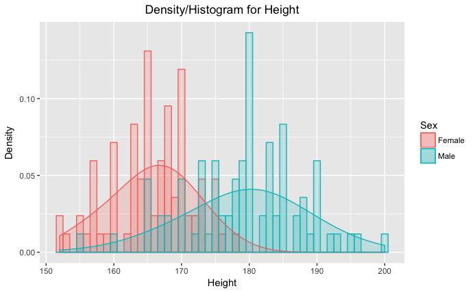

```r
ggplot(df, aes(x = Height, color = Sex, fill= Sex)) +
  geom_histogram(aes(y =..density..),position='identity',alpha=0.2, binwidth = 1) +
  geom_density(adjust=2,alpha=0.2) +
  labs(title='Density/Histogram for Height') +
  labs(x='Height', y='Density') +
  theme(plot.title = element_text(hjust = 0.5))
```

With a facet wrap, we get the following graph:

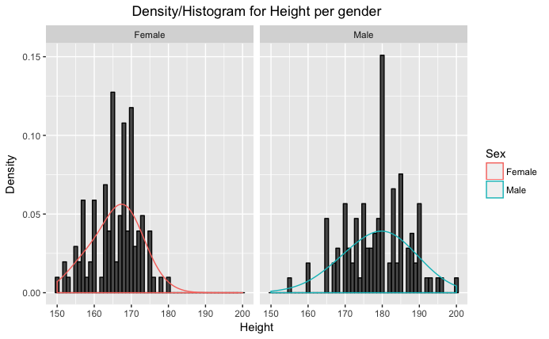

```r
df <- data.frame(survey)
df <- subset(df,!is.na(Sex))
ggplot(df, aes(x = Height, color = Sex)) +
  geom_histogram(aes(y =..density..),color=1, binwidth = 1) +
  geom_density(adjust=2) +
  labs(title='Density/Histogram for Height per gender') +
  labs(x='Height', y='Density') +
  facet_wrap(~Sex) +
  theme(plot.title = element_text(hjust = 0.5))
```

# Exercice 4:

- Question a:

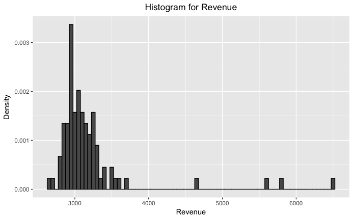

```r
library(lawstat)
library(dplyr)
df <- data.frame(zuni)
ggplot(df, aes(x = Revenue)) +
  geom_histogram(aes(y =..density..),col=1,binwidth = 50) +
  labs(title='Histogram for Revenue') +
  labs(x='Revenue', y='Density') +
  theme(plot.title = element_text(hjust = 0.5))
```

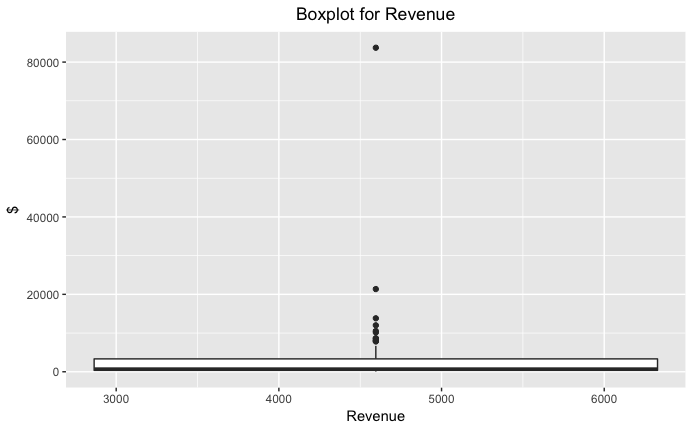

```r
ggplot(df, aes(x = Revenue, y = Mem)) +
  geom_boxplot() +
  labs(title='Boxplot for Revenue') +
  labs(x='Revenue', y='$') +
  theme(plot.title = element_text(hjust = 0.5))
```

- Question b:

```r
quantile(zuni$Revenue, 0.95)
```

```
   95%
3650.4
```

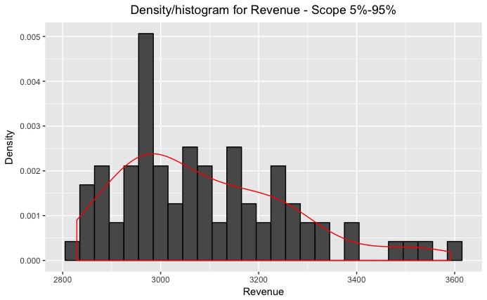

```r
zuni_5_95 <- zuni[(quantile(zuni$Revenue, 0.05) < zuni$Revenue) & (zuni$Revenue < quantile(zuni$Revenue, 0.95)), ]
ggplot(data=zuni_5_95, aes(zuni_5_95$Revenue)) +
  geom_histogram(aes(y =..density..), col=1, binwidth=30) +
  geom_density(col=2, adjust=1) +
  labs(title='Density/histogram for Revenue - Scope 5%-95%') +
  labs(x='Revenue', y='Density') +
  theme(plot.title = element_text(hjust = 0.5))
```

The foloowing distribution does not look symetric from the paramter we selected. The pic look centered on the left side of the graph and not in the middle. High value data make the graph not symetric.

- Question c:

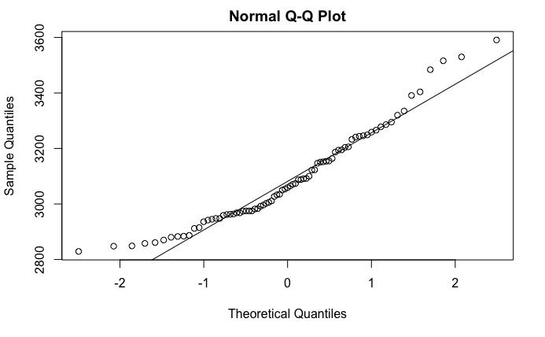

```r
qqnorm(zuni_5_95$Revenue)
qqline(zuni_5_95$Revenue)
```

The distribution is not normally distributed because of the highest and lowest value of the sample. If the sample was smaller, i.e the value in the middle of the graph, then the distribution would be normally distributed.

# Exercice 5:

- First graph:

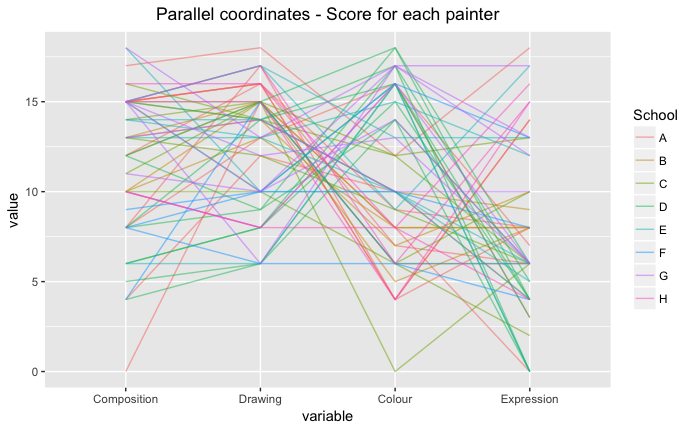

```r
require(GGally)
Names <- rownames(painters)
new_painters <- cbind(painters,Names)
ggparcoord(data=new_painters,
           columns = 1:4,
           groupColumn = 5,
           scale = 'globalminmax',
           shadeBox = NULL,
           alphaLines = 0.5,
           title = "Parallel coordinates - Score for each painter") +
           theme(plot.title = element_text(hjust = 0.5))
```

I try to gather in one graph the 5 differents type of information of the data table.

Assets of the graph:

– We can easily figure out his certain class of painters are more likely to be good in certain aspects. We can see if there is a trend in the data. For exemple, School D of painters are great at using colors. School A hqs a very sparse level in composition.

Drawbacks of the graph:

– Unfortunately the color are hard to distinguish. Since they are 54 entries, it makes the graph hard to read.

- Second graph:

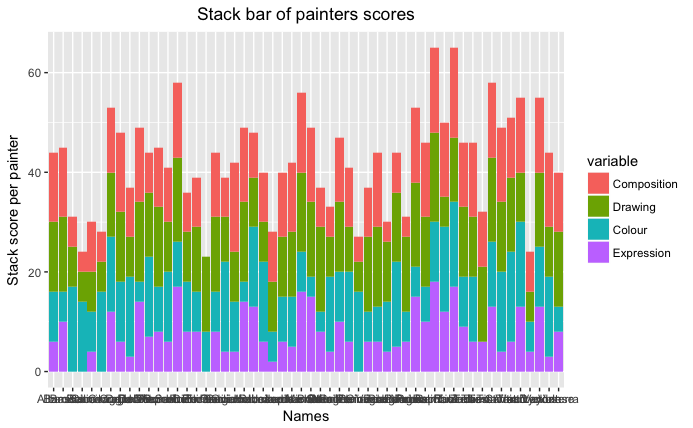

```r
library(reshape2)
data_painters <- painters
data_painters$School <- NULL
data_painters <- cbind(data_painters,Names)
dat.m <- melt(data_painters,id.vars = "Names")
ggplot(dat.m, aes(x = Names, y = value,fill=variable)) +
    geom_bar(stat='identity') + ylab("Stack score per painter") + ggtitle("Stack bar of painters scores") + theme(plot.title = element_text(hjust = 0.5))
```

This stack bar chart is useful to see the total score of each painter. It also help to identify their strengh and weaknesses. To contrast this comment, it is actually easy to compare the expression score between two painters but harder to compare the rest of the criteria between two painters. As the previous graph, it is also hard to see the x-axis to identify painters.

- Thrid graph:

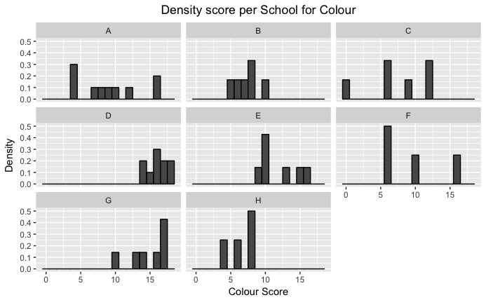

```r
ggplot(new_painters, aes(new_painters$Colour)) +
  geom_histogram(aes(y =..density..),binwidth = 1, col=1) + xlab("Colour Score") + ylab("Density") + ggtitle("Density score per School for Colour") + theme(plot.title = element_text(hjust = 0.5)) + facet_wrap(~new_painters$School)
```

This graph is a focus on the criteria Colour. It has been facet wrapped so we can try to understand possible trend in the data. For exemple, we can see that School D has a great usage of Colour. This was maybe a focus at the time. For some other schools, for exemple F, we can see that some painters have great score when others don’t, so we can not come to conclusions.